# Urban pollination networks with stochastic block models

R companion of the slides (running example: Baldock et al. 2019, 4 UK cities)

Author

Sophie Donnet (INRAE, MIA Paris-Saclay)

Online version of this companion: https://sophiedonnet.github.io/UrbanNetworks/companion_slides_UK.html (course page, with the slides and the downloads: https://sophiedonnet.github.io/urban_networks.html).

**NoteReferences**

**Data**

- Baldock, K. C. R., Goddard, M. A., Hicks, D. M., Kunin, W. E., Mitschunas, N., Morse, H., Osgathorpe, L. M., Potts, S. G., Robertson, K. M., Scott, A. V., Staniczenko, P. P. A., Stone, G. N., Vaughan, I. P. & Memmott, J. (2019). A systems approach reveals urban pollinator hotspots and conservation opportunities. *Nature Ecology & Evolution*, 3, 363–373. [doi:10.1038/s41559-018-0769-y](https://doi.org/10.1038/s41559-018-0769-y)
- Insect taxonomy completed with the compilation of Doré, M., Fontaine, C. & Thébault, E. (2021). Relative effects of anthropogenic pressures, climate, and sampling design on the structure of pollination networks at the global scale. *Global Change Biology*, 27(6), 1266–1280. [doi:10.1111/gcb.15474](https://doi.org/10.1111/gcb.15474)

**R packages**

- `sbm`: Chiquet, J., Donnet, S. & Barbillon, P. *sbm: Stochastic Blockmodels*. R package, [CRAN](https://CRAN.R-project.org/package=sbm) · [GitHub](https://github.com/GrossSBM/sbm)
- `colSBM`: SBM for collections of networks. R package, [GitHub](https://github.com/GrossSBM/colSBM). Method: Chabert-Liddell, S.-C., Barbillon, P. & Donnet, S. (2024). Learning common structures in a collection of networks. An application to food webs. *The Annals of Applied Statistics*, 18(2), 1213–1235. [doi:10.1214/23-AOAS1831](https://doi.org/10.1214/23-AOAS1831)

  Bipartite networks: Lacoste, L., Barbillon, P. & Donnet, S. (2025). Common structure discovery in collections of bipartite networks: application to pollination systems. Preprint, [arXiv:2512.01716](https://arxiv.org/abs/2512.01716) · [HAL: hal-05399136](https://hal.science/hal-05399136v1)

This document follows the sections of the slides and gives, for each figure, table or number of the slides, the R code that produces it.

The estimations are long (up to 1 h for a colSBM): they are cached in `results_analysis/`. Delete a file to re-estimate it.

The estimations can be launched with the scripts in the folder `scripts/`.

# 1 Setup

```r
library(dplyr)
library(tidyr)
library(ggplot2)
library(patchwork)
library(sbm)       # SBM on one network
library(colSBM)    # SBM on a collection of networks (>= 0.4.11, GitHub GrossSBM/colSBM)
library(bipartite) # d' specialisation index
library(vegan)     # NODF

col_plant <- "#66C1BF"; col_poll <- "#FFA500"   # colours of the slides
cols_status <- c(Native = col_plant, `Non-native` = col_poll, Mixed = "grey55", unknown = "grey85")
cols_group <- c(Bee = "#F2D04B", Hoverfly = "#D45E00", `Other Diptera` = "#7A5195",
                Beetle = "#2F7F5F", `Butterfly / moth` = "#3E7CB1", `Other Hymenoptera` = "grey60")
theme_set(theme_minimal(base_size = 14))

# estimate once, then read the cached result
cached_fit <- function(file, expr) {
  if (file.exists(file)) return(readRDS(file))
  set.seed(1)
  fit <- expr
  saveRDS(fit, file)
  fit
}
```

# 2 Motivation: the data

Baldock et al. (2019), *Nature Ecology & Evolution* 3: 363–373. 4 cities (Bristol, Edinburgh, Leeds, Reading) × 9 land uses, 360 sites. One record = one insect caught on one flower. The networks are built from the supplementary files of the paper (in `data_Baldock2019/`, see its `README.md` for the choices made) by `scripts/01_build_networks_Baldock2019.R`, which writes `data_Baldock2019/baldock2019_networks.rds`.

```r
baldock <- readRDS("data_Baldock2019/baldock2019_networks.rds")
head(baldock$records, 3)
```

```
# A tibble: 3 × 9
  city    landuse   site      plant           insect specimen status order group
  <chr>   <chr>     <chr>     <chr>           <chr>  <chr>    <chr>  <chr> <chr>
1 Bristol Allotment BR_ALT_01 Senecio jacoba… Lucil… BR_ALT_… Native Dipt… Othe…
2 Bristol Allotment BR_ALT_01 Bellis perennis Empis… BR_ALT_… Native Dipt… Othe…
3 Bristol Allotment BR_ALT_01 Origanum vulga… Sarco… BR_ALT_… Native Dipt… Othe…
```

```r
nrow(baldock$records)   # number of visits
```

```
[1] 4921
```

```r
# a network = a table plants x insects, counting the visits
net_city <- lapply(split(baldock$records, baldock$records$city),
                   function(d) unclass(table(d$plant, d$insect)))
all.equal(lapply(net_city, function(M) sum(M)), lapply(baldock$net_city, sum))
```

```
[1] TRUE
```

```r
net_city <- baldock$net_city
```

Plant status (native / non-native) and insect groups:

```r
plant_status <- setNames(baldock$plants$status, baldock$plants$plant)
plant_status[is.na(plant_status)] <- "unknown"
insect_group <- setNames(baldock$insects$group, baldock$insects$insect)
```

# 3 Introduction to networks

## 3.1 Graphs and matrices: the Bristol network

```r
M <- net_city$Bristol           # counts: plants x insects
B <- 1 * (M > 0)                # binary incidence matrix
c(plants = nrow(M), insects = ncol(M), links = sum(B), visits = sum(M))
```

```
 plants insects   links  visits
    193     180     662    1379
```

Slide *“Bristol: the count matrix”* and *“the weighted network”*: the count matrix, and the distribution of the counts per pair (plant, insect).

```r
pairs <- as.data.frame(as.table(M)) |> setNames(c("plant", "insect", "visits")) |> filter(visits > 0)
pairs |> slice_max(visits, n = 4)       # the largest counts
```

```
                plant                  insect visits
1 Solidago canadensis Reichertella geniculata     81
2    Senecio jacobaea    Eristalis arbustorum     41
3  Foeniculum vulgare        Lucilia sericata     41
4     Myrtus communis          Apis mellifera     33
```

```r
mean(pairs$visits == 1)                 # share of the pairs seen once
```

```
[1] 0.723565
```

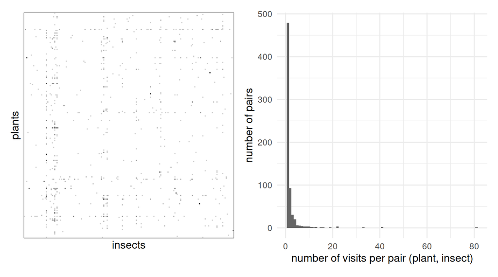

```r
plotMyMatrix(log1p(M), dimLabels = c(row = "plants", col = "insects")) +   # log scale: counts 1 to 81
  ggplot(pairs, aes(visits)) + geom_histogram(binwidth = 1, fill = "grey40") +
  labs(x = "number of visits per pair (plant, insect)", y = "number of pairs")
```

The bipartite graph and the binarised incidence matrix:

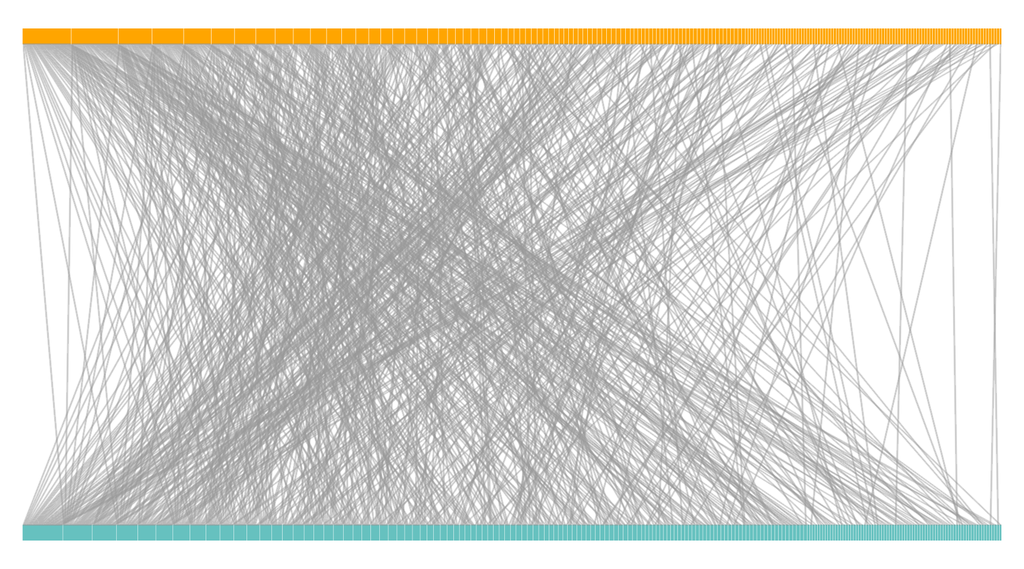

```r
plotweb(B, sorting = "dec", box_size = 0.03, higher_labels = rep("", ncol(B)), lower_labels = rep("", nrow(B)),
        higher_color = col_poll, lower_color = col_plant, link_color = "grey60", link_alpha = 0.3)
```

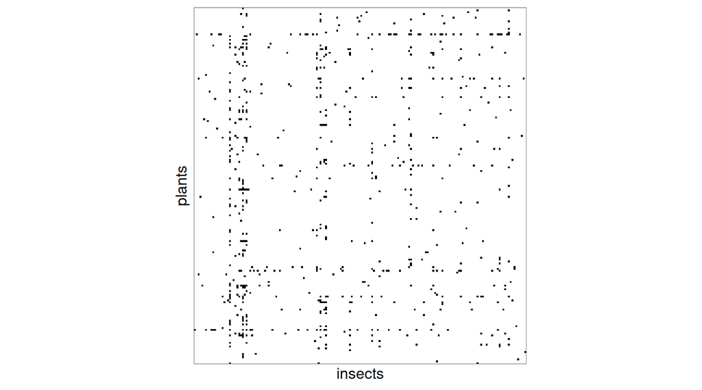

```r
plotMyMatrix(B, dimLabels = c(row = "plants", col = "insects"))
```

## 3.2 Node-level descriptors

Degree (number of partners) and strength (number of visits), slides *“Degree”*, *“Strength”*, *“Degree vs strength”*.

```r
nodes <- bind_rows(
  tibble(type = "plants", species = rownames(M), degree = rowSums(B), strength = rowSums(M)),
  tibble(type = "insects", species = colnames(M), degree = colSums(B), strength = colSums(M))) |>
  mutate(type = factor(type, levels = c("plants", "insects")))
nodes |> group_by(type) |> slice_max(degree, n = 3)   # Apis mellifera: 46 partners
```

```
# A tibble: 6 × 4
# Groups:   type [2]
  type    species           degree strength
  <fct>   <chr>              <dbl>    <dbl>
1 plants  Bellis perennis       38       61
2 plants  Taraxacum agg         27       55
3 plants  Ranunculus repens     22       46
4 insects Apis mellifera        46      162
5 insects Bombus pascuorum      44      118
6 insects Bombus terrestris     31       77
```

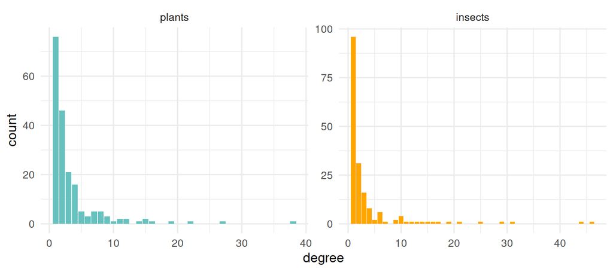

```r
ggplot(nodes, aes(degree, fill = type)) + geom_bar() +
  facet_wrap(~type, scales = "free") + scale_fill_manual(values = c(col_plant, col_poll), guide = "none")
```

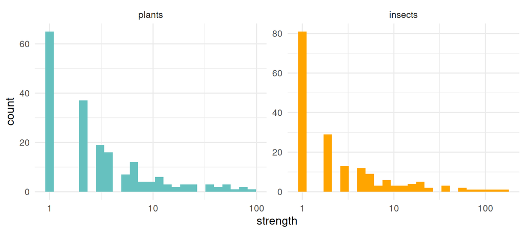

```r
ggplot(nodes, aes(strength, fill = type)) + geom_histogram(bins = 25) + scale_x_log10() +
  facet_wrap(~type, scales = "free") + scale_fill_manual(values = c(col_plant, col_poll), guide = "none")
```

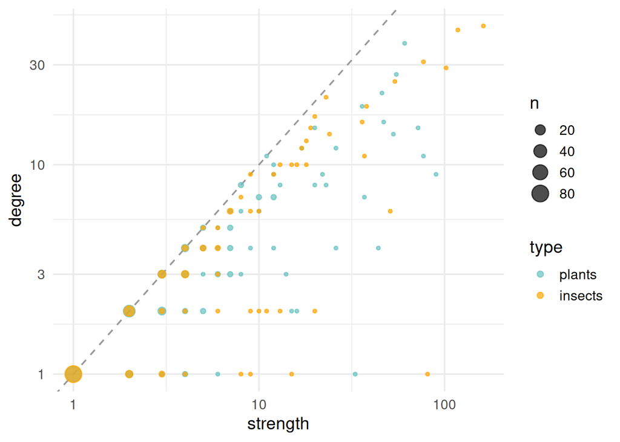

```r
ggplot(nodes, aes(strength, degree, colour = type)) +
  geom_abline(linetype = "dashed", colour = "grey60") + geom_count(alpha = 0.7) +
  scale_x_log10() + scale_y_log10() + scale_colour_manual(values = c(col_plant, col_poll))
```

Specialisation index $d'$ of the plants, native vs non-native (slide *“Specialisation index $d'$”*):

```r
dprime <- tibble(plant = rownames(M), dprime = dfun(M)$dprime, status = plant_status[rownames(M)]) |>
  filter(status %in% c("Native", "Non-native"))
dprime |> group_by(status) |> summarise(n = n(), median = median(dprime))
```

```
# A tibble: 2 × 3
  status         n median
  <chr>      <int>  <dbl>
1 Native        59  0.453
2 Non-native    81  0.401
```

```r
wilcox.test(dprime ~ status, data = dprime)
```

```
    Wilcoxon rank sum test with continuity correction

data:  dprime by status
W = 2587, p-value = 0.4057
alternative hypothesis: true location shift is not equal to 0
```

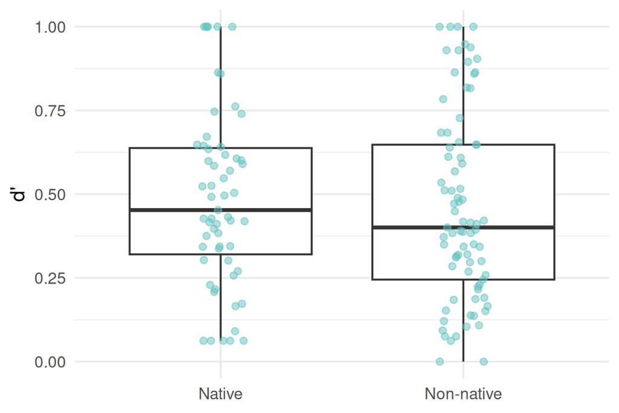

```r
ggplot(dprime, aes(status, dprime)) + geom_boxplot(outlier.shape = NA) +
  geom_jitter(width = 0.1, alpha = 0.5, colour = col_plant) + labs(x = NULL, y = "d'")
```

## 3.3 Network-level descriptors

Table of the slide *“Descriptors per city”*: connectance $C = L / (nm)$, interaction evenness $E$, nestedness NODF.

```r
network_metrics <- function(M) {
  B <- 1 * (M > 0); P <- M[M > 0] / sum(M)
  tibble(plants = nrow(B), insects = ncol(B), links = sum(B), visits = sum(M),
         C = round(mean(B), 3), E = round(-sum(P * log(P)) / log(sum(B)), 2),
         NODF = round(nestednodf(B)$statistic[["NODF"]], 1))
}
bind_rows(lapply(net_city, network_metrics), .id = "city") |> knitr::kable()
```

| city | plants | insects | links | visits | C | E | NODF |
| --- | --- | --- | --- | --- | --- | --- | --- |
| Bristol | 193 | 180 | 662 | 1379 | 0.019 | 0.90 | 10.1 |
| Edinburgh | 137 | 129 | 425 | 1507 | 0.024 | 0.73 | 12.9 |
| Leeds | 155 | 126 | 573 | 1079 | 0.029 | 0.94 | 13.3 |
| Reading | 156 | 167 | 574 | 956 | 0.022 | 0.95 | 12.6 |

# 4 Introduction to stochastic block models

## 4.1 The simplest model: Erdős–Rényi

$Y_{ij} \sim \mathcal{B}ern(p)$, $\hat p = C$: the degrees would be Binomial.

```r
p_hat <- mean(B); p_hat
```

```
[1] 0.01905584
```

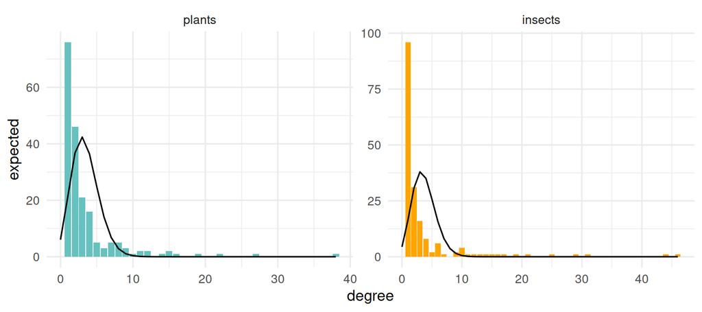

```r
er <- bind_rows(tibble(type = "plants", degree = 0:50, expected = nrow(B) * dbinom(0:50, ncol(B), p_hat)),
                tibble(type = "insects", degree = 0:50, expected = ncol(B) * dbinom(0:50, nrow(B), p_hat))) |>
  mutate(type = factor(type, levels = c("plants", "insects"))) |>
  filter(degree <= ifelse(type == "plants", max(rowSums(B)), max(colSums(B))))
ggplot(nodes, aes(degree)) + geom_bar(aes(fill = type)) +
  geom_line(data = er, aes(y = expected)) + facet_wrap(~type, scales = "free") +
  scale_fill_manual(values = c(col_plant, col_poll), guide = "none")
```

## 4.2 Bipartite SBM on simulated networks

*“One model, many structures”*: modular, core–periphery and nested structures simulated with `sampleBipartiteSBM`, then *“What inference does”*: the groups are recovered from a matrix in an arbitrary order.

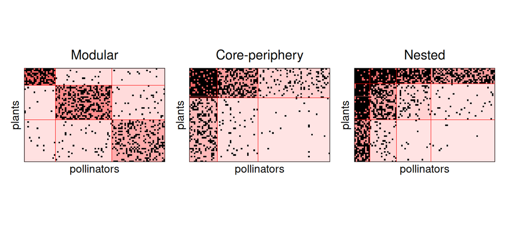

```r
set.seed(2)
structures <- list(
  Modular = list(alpha = matrix(c(.60, .05, .02, .03, .40, .05, .02, .04, .25), 3, byrow = TRUE),
                 pi = c(.2, .3, .5), rho = c(.25, .35, .4)),
  `Core-periphery` = list(alpha = matrix(c(.85, .45, .15, .30, .05, .01), 2, byrow = TRUE),
                          pi = c(.3, .7), rho = c(.15, .35, .5)),
  Nested = list(alpha = matrix(c(.95, .85, .70, .50, .85, .45, .15, .03, .60, .10, .02, .01), 3, byrow = TRUE),
                pi = c(.2, .3, .5), rho = c(.1, .2, .3, .4)))
sims <- lapply(structures, function(s)
  sampleBipartiteSBM(nbNodes = c(60, 90), blockProp = list(row = s$pi, col = s$rho),
                     connectParam = list(mean = s$alpha), model = "bernoulli",
                     dimLabels = c(row = "plants", col = "pollinators")))
wrap_plots(lapply(names(sims), function(s) plot(sims[[s]], type = "data") + ggtitle(s)))
```

```r
Y <- sims$Modular$networkData
Y <- Y[sample(nrow(Y)), sample(ncol(Y))]          # arbitrary order, as observed
fit_sim <- estimateBipartiteSBM(Y, model = "bernoulli", estimOptions = list(verbosity = 0, plot = FALSE))
```

```r
fit_sim$nbBlocks
```

```
row col
  3   3
```

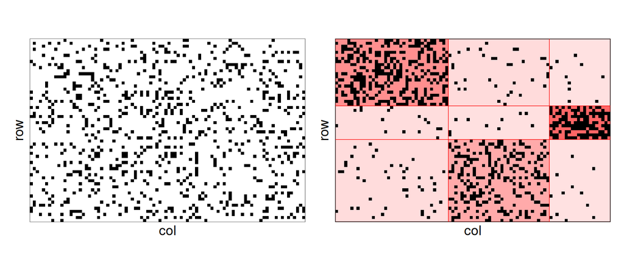

```r
plotMyMatrix(Y) + plot(fit_sim, type = "data")
```

## 4.3 Application to the UK data

One bipartite SBM per city, on the counts (Poisson) and on the binary networks (Bernoulli). `estimateBipartiteSBM` explores the numbers of groups $(K, L)$ and keeps the best ICL.

```r
net_bin <- lapply(net_city, function(M) 1 * (M > 0))
sbm_opts <- list(verbosity = 0, plot = FALSE, nbCores = 4)
fit_bin <- cached_fit("results_analysis/results_city_SBM_bernoulli.rds",
  lapply(net_bin, estimateBipartiteSBM, model = "bernoulli",
         dimLabels = c(row = "plants", col = "insects"), estimOptions = sbm_opts))
fit_pois <- cached_fit("results_analysis/results_city_SBM_poisson.rds",
  lapply(net_city, estimateBipartiteSBM, model = "poisson",
         dimLabels = c(row = "plants", col = "insects"), estimOptions = sbm_opts))
```

Slide *“ICL versus BIC”*: the criteria along the explored models (Bristol, binary).

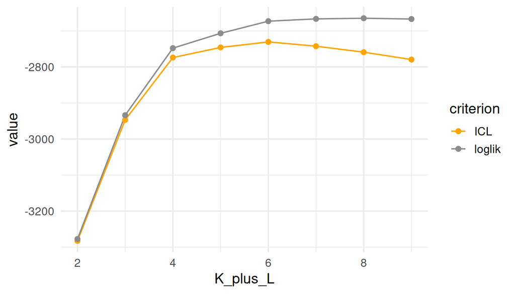

```r
fit_bin$Bristol$storedModels |>
  mutate(K_plus_L = nbRowBlocks + nbColBlocks) |>
  pivot_longer(c(ICL, loglik), names_to = "criterion") |>
  ggplot(aes(K_plus_L, value, colour = criterion)) + geom_line() + geom_point() +
  scale_colour_manual(values = c(ICL = col_poll, loglik = "grey55"))
```

### 4.3.1 Bristol: SBM on the counts

```r
fp <- fit_pois$Bristol
fp$nbBlocks
```

```
 plants insects
      7       6
```

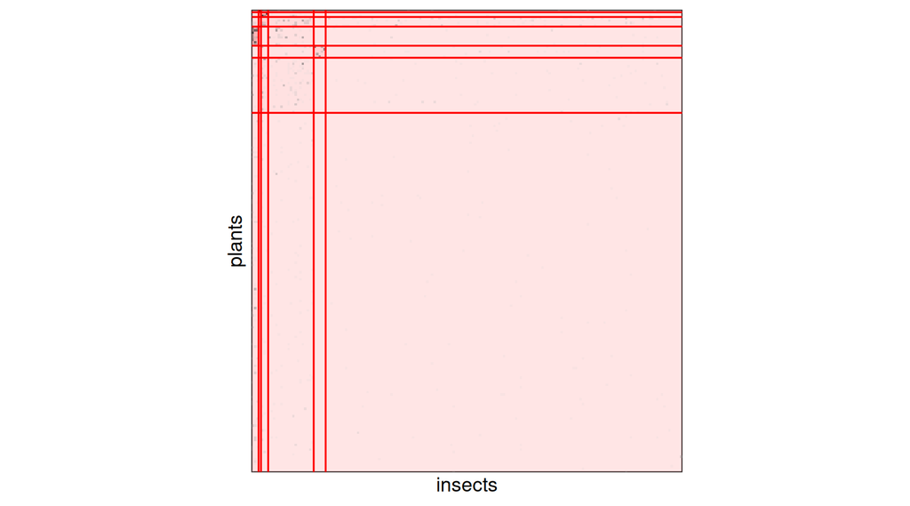

```r
# counts on a log scale, ordered by the estimated groups
plot_counts <- function(fit) plotMyMatrix(log1p(fit$networkData), dimLabels = c(row = "plants", col = "insects"),
  clustering = list(row = fit$memberships$plants, col = fit$memberships$insects))
plot_counts(fp)
```

The groups mostly sort species by their number of visits:

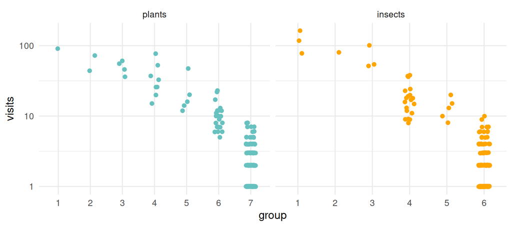

```r
bind_rows(tibble(type = "plants", group = fp$memberships$plants, visits = rowSums(fp$networkData)),
          tibble(type = "insects", group = fp$memberships$insects, visits = colSums(fp$networkData))) |>
  mutate(type = factor(type, levels = c("plants", "insects"))) |>
  ggplot(aes(factor(group), visits, colour = type)) + geom_jitter(width = 0.15) +
  scale_y_log10() + facet_wrap(~type, scales = "free_x") +
  scale_colour_manual(values = c(insects = col_poll, plants = col_plant), guide = "none") + labs(x = "group")
```

### 4.3.2 Edinburgh: one insect drives the counts

*Reichertella geniculata*: 300 visits on *Taraxacum* at one site. The Poisson SBM with and without this insect:

```r
reich <- "Reichertella geniculata"
baldock$records |> filter(insect == reich) |> count(site, plant, sort = TRUE) |> head(3)
```

```
# A tibble: 3 × 3
  site      plant                   n
  <chr>     <chr>               <int>
1 ED_OGS_09 Taraxacum agg         300
2 ED_ALT_09 Cirsium arvense       162
3 BR_ALT_04 Solidago canadensis    81
```

```r
fit_pois_noR <- cached_fit("results_analysis/results_city_SBM_poisson_without_reichertella.rds",
  lapply(net_city, function(M) {
    M <- M[, colnames(M) != reich]
    M <- M[rowSums(M) > 0, colSums(M) > 0]          # plants visited only by this insect
    estimateBipartiteSBM(M, model = "poisson", dimLabels = c(row = "plants", col = "insects"),
                         estimOptions = sbm_opts)
  }))
c(with = fit_pois$Edinburgh$nbBlocks, without = fit_pois_noR$Edinburgh$nbBlocks)
```

```
    with.plants    with.insects  without.plants without.insects
              7               7               4               6
```

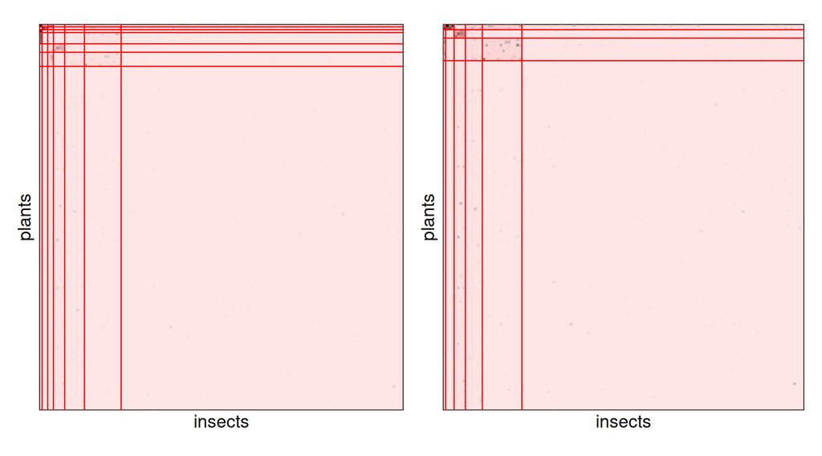

```r
plot_counts(fit_pois$Edinburgh) + plot_counts(fit_pois_noR$Edinburgh)
```

### 4.3.3 Bristol: SBM on the binary network

```r
fb <- fit_bin$Bristol
fb$nbBlocks
```

```
 plants insects
      3       3
```

```r
round(fb$connectParam$mean, 2)        # alpha_kl
```

```
     [,1] [,2] [,3]
[1,] 0.28 0.31 0.11
[2,] 0.39 0.22 0.02
[3,] 0.14 0.03 0.00
```

```r
lapply(fb$blockProp, round, 2)         # pi_k, rho_l
```

```
$plants
[1] 0.02 0.13 0.85

$insects
[1] 0.03 0.09 0.88
```

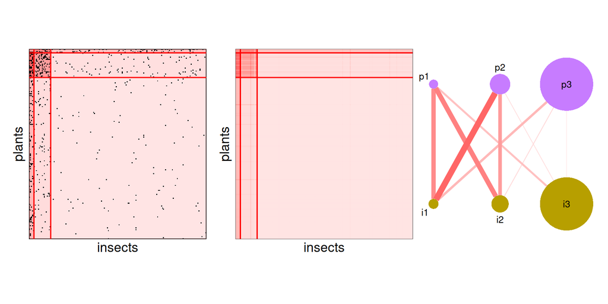

```r
plot(fb, type = "data") + plot(fb, type = "expected") + plot(fb, type = "meso")
```

Species of the core groups (*“Bristol: interpretation”*):

```r
core_p <- which.max(rowSums(fb$connectParam$mean)); core_i <- which.max(colSums(fb$connectParam$mean))
rownames(fb$networkData)[fb$memberships$plants == core_p]
```

```
[1] "Bellis perennis"       "Heracleum sphondylium" "Ranunculus repens"
[4] "Taraxacum agg"
```

```r
colnames(fb$networkData)[fb$memberships$insects == core_i]
```

```
[1] "Apis mellifera"       "Bombus pascuorum"     "Bombus terrestris"
[4] "Eristalis arbustorum" "Eristalis tenax"
```

```r
table(plants = fb$memberships$plants); table(insects = fb$memberships$insects)
```

```
plants
  1   2   3
  4  25 164
```

```
insects
  1   2   3
  5  17 158
```

Composition of the groups: plant status and insect group (*“Bristol: composition of the groups”*).

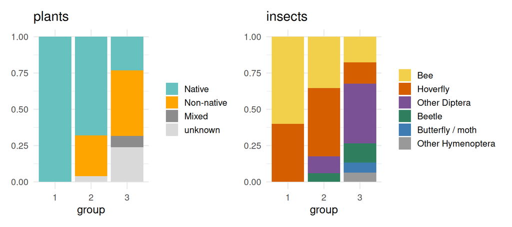

```r
composition <- function(group, value, cols, title) {
  tibble(group = factor(group), value = factor(value, levels = names(cols))) |>
    ggplot(aes(group, fill = value)) + geom_bar(position = "fill") +
    scale_fill_manual(values = cols, name = NULL) + labs(y = NULL, title = title)
}
composition(fb$memberships$plants, plant_status[rownames(fb$networkData)], cols_status, "plants") +
  composition(fb$memberships$insects, insect_group[colnames(fb$networkData)], cols_group, "insects")
```

### 4.3.4 One SBM per city

```r
tibble(city = names(net_city),
       Bernoulli = sapply(fit_bin, function(f) paste(f$nbBlocks, collapse = " x ")),
       Poisson = sapply(fit_pois, function(f) paste(f$nbBlocks, collapse = " x "))) |>
  knitr::kable()
```

| city | Bernoulli | Poisson |
| --- | --- | --- |
| Bristol | 3 x 3 | 7 x 6 |
| Edinburgh | 3 x 3 | 7 x 7 |
| Leeds | 2 x 3 | 5 x 6 |
| Reading | 3 x 3 | 5 x 6 |

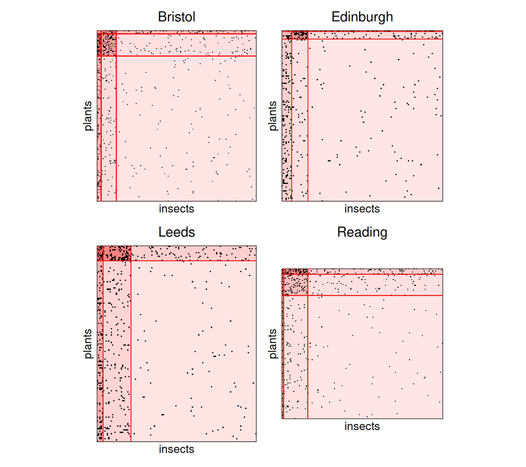

```r
wrap_plots(lapply(names(fit_bin), function(cc) plot(fit_bin[[cc]], type = "data") + ggtitle(cc)), nrow = 2)
```

*“Most species are seen in one city”*:

```r
n_cities <- bind_rows(
  tibble(type = "plants", species = unlist(lapply(net_city, rownames))),
  tibble(type = "insects", species = unlist(lapply(net_city, colnames)))) |>
  count(type, species, name = "n_cities") |> mutate(type = factor(type, levels = c("plants", "insects")))
table(n_cities$type, n_cities$n_cities)
```

```
            1   2   3   4
  plants  226  77  35  39
  insects 195  54  45  41
```

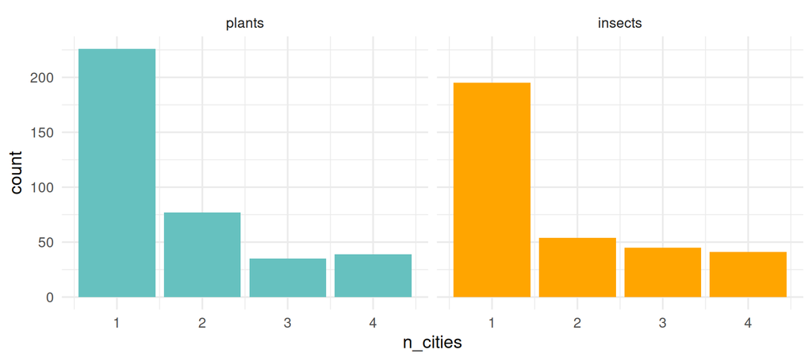

```r
ggplot(n_cities, aes(n_cities, fill = type)) + geom_bar() + facet_wrap(~type) +
  scale_fill_manual(values = c(insects = col_poll, plants = col_plant), guide = "none")
```

# 5 Modelling collections of networks

## 5.1 Application to the city networks

`estimate_colBiSBM` fits the colBiSBM on the 4 binary networks, and the separate SBMs (`sep_BiSBM`) for comparison. Models: `iid` (same $\alpha$, same proportions), `pi` / `rho` (free plant / insect proportions). About 30 min per model (`scripts/fit_colSBM_cities.R`).

```r
col_fits <- lapply(c(iid = "iid", pi = "pi", rho = "rho"), function(model)
  cached_fit(paste0("results_analysis/results_city_colBiSBM_", model, ".rds"),
    estimate_colBiSBM(netlist = net_bin, colsbm_model = model, net_id = names(net_bin),
                      distribution = "bernoulli", nb_run = 3,
                      global_opts = list(nb_cores = max(1, parallel::detectCores() - 1),
                                         verbosity = 0, plot_details = 0))))
```

*“Joint or separate models?”*: the BICL of the joint models and of the separate SBMs.

```r
bind_rows(
  tibble(model = "sep-BiSBM (one per city)",
         blocks = paste(sapply(col_fits$iid$sep_BiSBM$models, function(m) paste(m$Q, collapse = "x")), collapse = ", "),
         BICL = sum(col_fits$iid$sep_BiSBM$BICL)),
  tibble(model = paste0(names(col_fits), "-colBiSBM"),
         blocks = sapply(col_fits, function(f) paste(f$best_fit$Q, collapse = " x ")),
         BICL = sapply(col_fits, function(f) f$best_fit$BICL))) |>
  mutate(BICL = round(BICL)) |> knitr::kable()
```

| model | blocks | BICL |
| --- | --- | --- |
| sep-BiSBM (one per city) | 3x3, 3x3, 2x3, 3x3 | -8780 |
| iid-colBiSBM | 5 x 3 | -8651 |
| pi-colBiSBM | 5 x 3 | -8677 |
| rho-colBiSBM | 5 x 3 | -8665 |

### 5.1.1 The common structure

$\hat\alpha_{k\ell}$ shared by the 4 cities, with the block proportions $\hat\pi_k$, $\hat\rho_\ell$:

```r
fit <- col_fits$iid$best_fit
round(fit$alpha, 2)
```

```
     [,1] [,2] [,3]
[1,] 0.35 0.51 0.19
[2,] 0.40 0.29 0.07
[3,] 0.35 0.17 0.02
[4,] 0.22 0.03 0.00
[5,] 0.04 0.04 0.01
```

```r
lapply(fit$pi[[1]], round, 2)
```

```
[[1]]
[1] 0.01 0.04 0.12 0.49 0.34

[[2]]
[1] 0.04 0.13 0.84
```

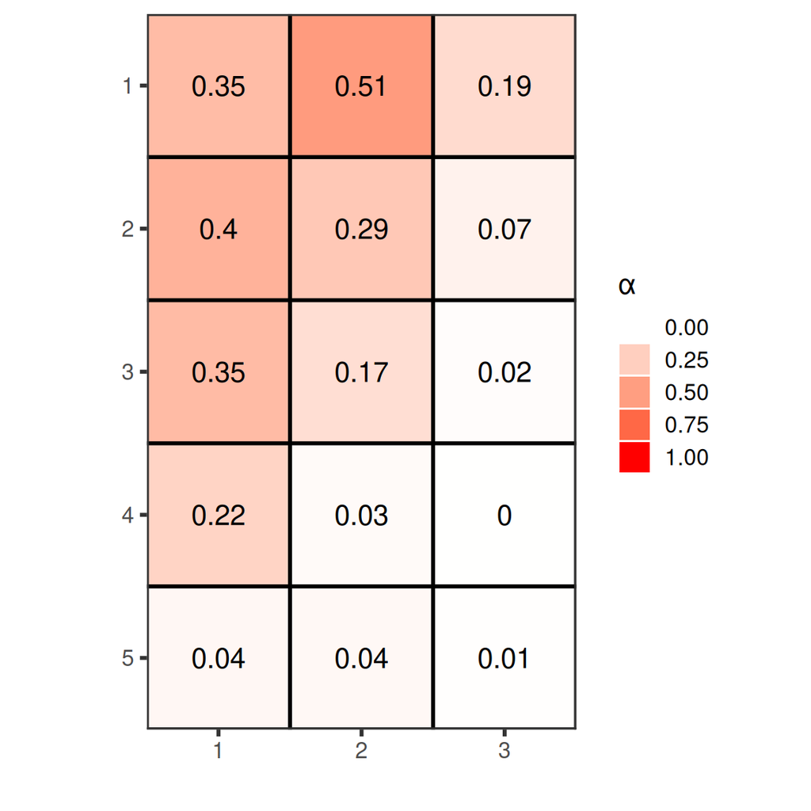

```r
plot(fit, type = "meso", values = TRUE)
```

*“The same groups in every city”*: each city reordered by the joint groups.

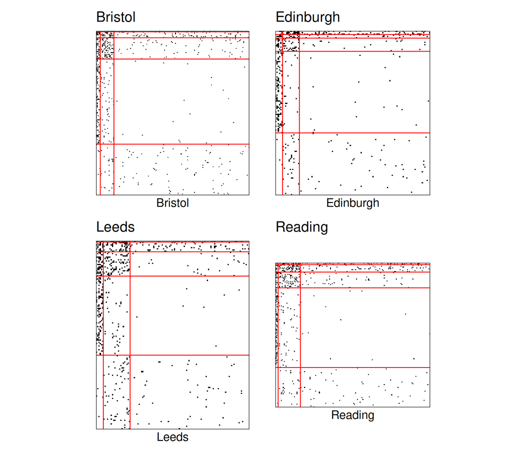

```r
wrap_plots(lapply(seq_along(fit$net_id), function(m)
  plot(fit, type = "block", net_id = m) + ggtitle(fit$net_id[m])), nrow = 2)
```

The joint groups of each species in each city:

```r
groups <- extract_nodes_groups(fit) |>
  mutate(type = ifelse(node_type == "row", "plant", "insect"),
         value = ifelse(type == "plant", plant_status[node_name], insect_group[node_name])) |>
  rename(city = network, species = node_name, block = cluster)
head(groups)
```

```
  city                species block node_type  type   value
1    1        Acanthus mollis     4       row plant unknown
2    1 Achillea filipendulina     5       row plant unknown
3    1     Alliaria petiolata     5       row plant  Native
4    1    Allium ampeloprasum     4       row plant   Mixed
5    1            Allium cepa     4       row plant   Mixed
6    1         Allium ursinum     5       row plant   Mixed
```

*“Joint modelling: more statistical power”*: number of species of each plant group per city (P1: 1 to 3 species per city).

```r
groups |> filter(type == "plant") |> count(city, block = paste0("P", block)) |>
  pivot_wider(names_from = block, values_from = n, values_fill = 0)
```

```
# A tibble: 4 × 6
  city     P1    P2    P3    P4    P5
  <chr> <int> <int> <int> <int> <int>
1 1         1     7    25   100    60
2 2         3     3    11    68    52
3 3         1     8    20    65    61
4 4         2     8    17    86    43
```

*“The 4 cities: composition of the groups”* (a species seen in 2 cities counts twice):

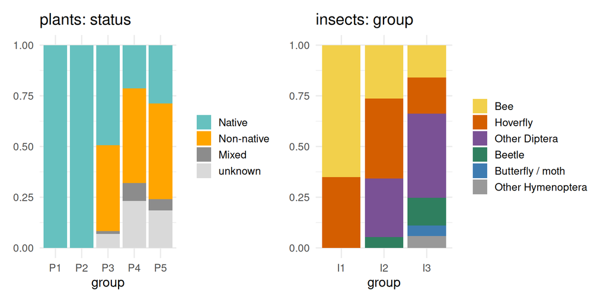

```r
with(filter(groups, type == "plant"), composition(paste0("P", block), value, cols_status, "plants: status")) +
  with(filter(groups, type == "insect", !is.na(value)),
       composition(paste0("I", block), value, cols_group, "insects: group"))
```

```r
g_bristol <- filter(groups, city == "Bristol")
table(separate = fb$memberships$plants[match(g_bristol$species[g_bristol$type == "plant"], rownames(fb$networkData))],
      joint = g_bristol$block[g_bristol$type == "plant"])
```

```
< table of extent 0 x 0 >
```

```r
table(separate = fb$memberships$insects[match(g_bristol$species[g_bristol$type == "insect"], colnames(fb$networkData))],
      joint = g_bristol$block[g_bristol$type == "insect"])
```

```
< table of extent 0 x 0 >
```

### 5.1.2 Does a species keep its group across cities?

For each species seen in 2 cities and each pair of cities: its group in the two cities.

```r
pairs_cities <- inner_join(groups, groups, by = c("type", "species"), relationship = "many-to-many") |>
  filter(city.x < city.y)
pairs_cities |> group_by(type) |> summarise(same_group = mean(block.x == block.y))
```

```
# A tibble: 2 × 2
  type   same_group
  <chr>       <dbl>
1 insect      0.8
2 plant       0.522
```

```r
with(filter(pairs_cities, type == "plant"), table(pmin(block.x, block.y), pmax(block.x, block.y)))
```

```
      1   2   3   4   5
  1   6   8   1   0   0
  2   0  16  18   4   8
  3   0   0  21  58  29
  4   0   0   0 116  73
  5   0   0   0   0  58
```

```r
with(filter(pairs_cities, type == "insect"), table(pmin(block.x, block.y), pmax(block.x, block.y)))
```

```
      1   2   3
  1  19  18   4
  2   0  61  65
  3   0   0 268
```

*“The insects that change group”*:

```r
changing <- groups |> filter(type == "insect") |> group_by(species) |>
  filter(n() > 1, n_distinct(block) > 1) |> mutate(mean_block = mean(block)) |> ungroup()
c(changing = n_distinct(changing$species),
  seen_in_several_cities = sum(table(groups$species[groups$type == "insect"]) > 1))
```

```
              changing seen_in_several_cities
                    28                    140
```

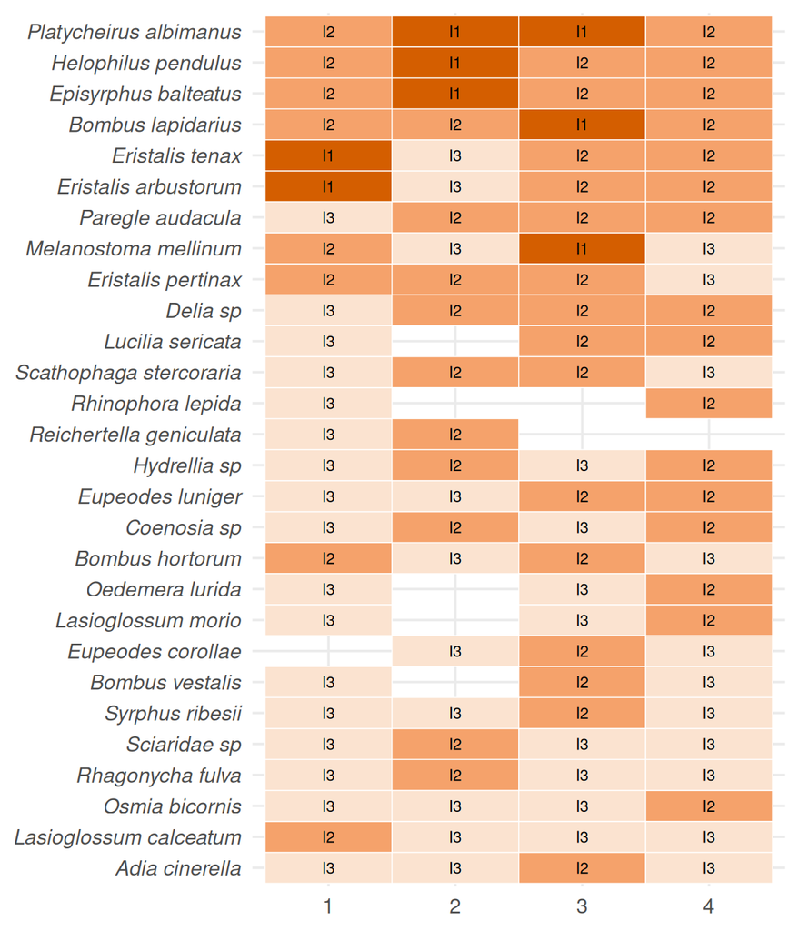

```r
ggplot(changing, aes(city, reorder(species, -mean_block), fill = paste0("I", block))) +
  geom_tile(colour = "white") + geom_text(aes(label = paste0("I", block)), size = 3) +
  scale_fill_manual(values = c(I1 = "#D45E00", I2 = "#F5A26B", I3 = "#FBE3D0"), guide = "none") +
  labs(x = NULL, y = NULL) + theme(axis.text.y = element_text(face = "italic"))
```

*“Ecological messages”* and *“A nested backbone”*: the core groups hold species seen in many cities, the peripheral groups species seen in 1 or 2 cities.

```r
groups |> left_join(n_cities |> mutate(type = sub("s$", "", type)), by = c("type", "species")) |>
  group_by(type, block) |>
  summarise(n = n(), seen_in_4_cities = round(mean(n_cities == 4), 2), .groups = "drop")
```

```
# A tibble: 8 × 4
  type   block     n seen_in_4_cities
  <chr>  <int> <int>            <dbl>
1 insect     1    20             1
2 insect     2    76             0.75
3 insect     3   506             0.17
4 plant      1     7             1
5 plant      2    26             0.77
6 plant      3    73             0.45
7 plant      4   319             0.18
8 plant      5   216             0.18
```

```r
groups |> filter(type == "plant", block <= 2) |> count(block, species, sort = TRUE) |> head(10)
```

```
   block                   species n
1      2         Ranunculus repens 4
2      1           Bellis perennis 3
3      1             Taraxacum agg 3
4      2      Rubus fruticosus agg 3
5      2          Senecio jacobaea 3
6      2           Cirsium arvense 2
7      2     Heracleum sphondylium 2
8      2      Leucanthemum vulgare 2
9      2 Scorzoneroides autumnalis 2
10     1     Heracleum sphondylium 1
```

## 5.2 Application to the land uses

One network per land use, pooled over the 4 cities (*“The 9 land-use networks”*):

```r
net_lu <- lapply(baldock$net_landuse, function(M) 1 * (M > 0))
tibble(land_use = names(net_lu), visits = sapply(baldock$net_landuse, sum),
       plants = sapply(net_lu, nrow), insects = sapply(net_lu, ncol),
       connectance = round(sapply(net_lu, mean), 3)) |>
  arrange(desc(visits)) |> knitr::kable()
```

| land_use | visits | plants | insects | connectance |
| --- | --- | --- | --- | --- |
| Allotment | 1657 | 180 | 155 | 0.024 |
| Garden | 1060 | 237 | 145 | 0.019 |
| Cemetery | 540 | 50 | 120 | 0.043 |
| Other greenspace | 530 | 25 | 62 | 0.072 |
| Nature reserve | 467 | 52 | 113 | 0.037 |
| Park | 385 | 42 | 100 | 0.051 |
| Verge | 207 | 28 | 72 | 0.061 |
| Pavement | 47 | 20 | 22 | 0.075 |
| Manmade surface | 28 | 12 | 15 | 0.117 |

`clusterize_bipartite_networks` looks for a partition of the networks into groups, each modelled by its own colBiSBM (divisive algorithm, score = sum of the BICL of the groups). The scores of all the steps (the trees of the slides) are printed during the fit with `verbosity = 1`; the result keeps the final partition.

```r
partition_table <- function(clu) {
  bind_rows(lapply(clu$partition, function(p) tibble(
    group = paste(p$best_fit$net_id, collapse = ", "),
    blocks = paste(p$best_fit$Q, collapse = " x "), BICL = round(p$best_fit$BICL, 1)))) |>
    mutate(score = sum(BICL))
}
opts_clu <- list(nb_cores = max(1, parallel::detectCores() - 1), verbosity = 1, plot_details = 0)
```

### 5.2.1 The 9 land uses ($\pi\rho$-colBiSBM)

About 1.5 h (`scripts/fit_colSBM_landuse.R`).

```r
clu9 <- cached_fit("results_analysis/results_landuse_colBiSBM_clustering_pirho.rds",
  clusterize_bipartite_networks(netlist = net_lu, colsbm_model = "pirho", net_id = names(net_lu),
                                nb_run = 3, global_opts = opts_clu))
clu9$clustering_history
```

```
  Allotment Cemetery Garden Manmade surface Nature reserve Other greenspace
1         1        1      1               1              1                1
2         1        1      1               2              1                1
  Park Pavement Verge
1    1        1     1
2    1        1     1
```

```r
partition_table(clu9) |> knitr::kable()
```

| group | blocks | BICL | score |
| --- | --- | --- | --- |
| Allotment, Cemetery, Garden, Nature reserve, Other greenspace, Park, Pavement, Verge | 4 x 4 | -8659.7 | -8727.1 |
| Manmade surface | 1 x 1 | -67.4 | -8727.1 |

### 5.2.2 Without the 3 small land uses (iid-colBiSBM)

Other greenspace, Pavement and Man-made surface removed. About 10 min (`scripts/fit_colSBM_landuse6_clustering.R`).

```r
landuses6 <- c("Allotment", "Cemetery", "Garden", "Nature reserve", "Park", "Verge")
clu6 <- cached_fit("results_analysis/results_landuse6_colBiSBM_clustering_iid.rds",
  clusterize_bipartite_networks(netlist = net_lu[landuses6], colsbm_model = "iid", net_id = landuses6,
                                nb_run = 3, global_opts = opts_clu))
clu6$clustering_history
```

```
  Allotment Cemetery Garden Nature reserve Park Verge
1         1        1      1              1    1     1
2         1        2      1              2    2     2
```

```r
partition_table(clu6) |> knitr::kable()
```

| group | blocks | BICL | score |
| --- | --- | --- | --- |
| Allotment, Garden | 3 x 4 | -5291.8 | -8159.8 |
| Cemetery, Nature reserve, Park, Verge | 3 x 3 | -2868.0 | -8159.8 |

```r
fits6 <- lapply(clu6$partition, function(p) p$best_fit)
names(fits6) <- ifelse(sapply(fits6, function(f) "Cemetery" %in% f$net_id), "greenspaces", "gardened")
```

### 5.2.3 Two different structures

Graphon view (*“Two different structures: graphon view”*) and $\hat\alpha$ of each group:

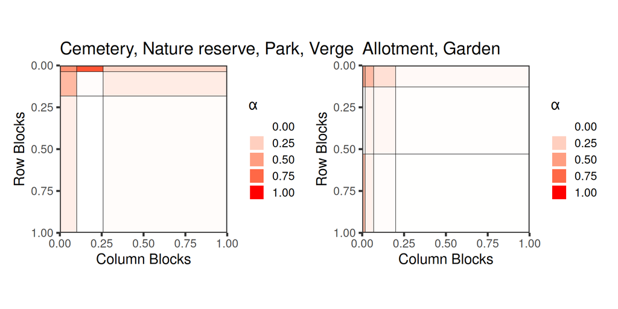

```r
plot(fits6$greenspaces, type = "graphon") + ggtitle("Cemetery, Nature reserve, Park, Verge") +
  plot(fits6$gardened, type = "graphon") + ggtitle("Allotment, Garden")
```

```r
lapply(fits6, function(f) round(f$alpha, 2))
```

```
$gardened
     [,1] [,2] [,3] [,4]
[1,] 0.47 0.35 0.16 0.03
[2,] 0.36 0.07 0.02 0.00
[3,] 0.00 0.07 0.04 0.01

$greenspaces
     [,1] [,2] [,3]
[1,] 0.57 0.83 0.22
[2,] 0.37 0.02 0.10
[3,] 0.09 0.00 0.02
```

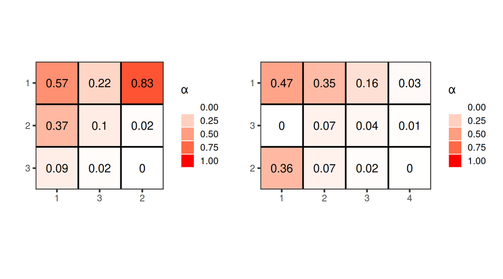

```r
plot(fits6$greenspaces, type = "meso", values = TRUE) | plot(fits6$gardened, type = "meso", values = TRUE)
```

### 5.2.4 Greenspaces: a core–periphery

```r
g_green <- extract_nodes_groups(fits6$greenspaces) |>
  mutate(type = ifelse(node_type == "row", "plant", "insect"),
         value = ifelse(type == "plant", plant_status[node_name], insect_group[node_name]))
# plants of the two core groups (all land uses pooled), with their status
g_green |> filter(type == "plant", cluster <= 2) |> distinct(cluster, node_name, value) |> arrange(cluster)
```

```
   cluster                 node_name  value
1        1           Bellis perennis Native
2        1     Heracleum sphondylium Native
3        1             Taraxacum agg Native
4        2     Anthriscus sylvestris Native
5        2         Crepis capillaris Native
6        2      Hypochaeris radicata Native
7        2      Leucanthemum vulgare Native
8        2         Ranunculus repens Native
9        2 Scorzoneroides autumnalis Native
10       2          Senecio jacobaea Native
11       2             Taraxacum agg Native
12       2           Cirsium arvense Native
13       2          Ranunculus acris Native
14       2      Rubus fruticosus agg Native
15       2   Chamerion angustifolium Native
16       2     Heracleum sphondylium Native
17       2          Trifolium repens Native
```

```r
# insect groups: composition
g_green |> filter(type == "insect") |> count(cluster, value) |> group_by(cluster) |>
  mutate(p = round(n / sum(n), 2)) |> select(-n) |> pivot_wider(names_from = value, values_from = p, values_fill = 0)
```

```
# A tibble: 3 × 8
# Groups:   cluster [3]
  cluster   Bee Hoverfly `Other Diptera` Beetle `Butterfly / moth`
    <int> <dbl>    <dbl>           <dbl>  <dbl>              <dbl>
1       1  0.39     0.37            0.24   0                  0
2       2  0.07     0.15            0.59   0.08               0.02
3       3  0.15     0.23            0.37   0.17               0.04
# ℹ 2 more variables: `Other Hymenoptera` <dbl>, `NA` <dbl>
```

### 5.2.5 Gardens: bee flowers vs fly flowers

```r
g_gard <- extract_nodes_groups(fits6$gardened) |>
  mutate(type = ifelse(node_type == "row", "plant", "insect"),
         value = ifelse(type == "plant", plant_status[node_name], insect_group[node_name]))
g_gard |> filter(type == "plant") |> count(cluster, value) |>
  pivot_wider(names_from = value, values_from = n, values_fill = 0)
```

```
# A tibble: 3 × 5
  cluster Mixed Native `Non-native` unknown
    <int> <int>  <int>        <int>   <int>
1       1     1     21           25       3
2       2    16     30           71      43
3       3    19     47           87      54
```

```r
# insects in I2 in one land use and in I3 in the other
g_gard |> filter(type == "insect") |> group_by(node_name) |>
  filter(n() == 2, n_distinct(cluster) == 2) |> ungroup() |> count(network, cluster)
```

```
# A tibble: 7 × 3
  network cluster     n
  <chr>     <int> <int>
1 1             1     1
2 1             2     5
3 1             3     9
4 1             4     4
5 2             2     3
6 2             3     9
7 2             4     7
```

# 6 Session

```r
packageVersion("colSBM"); packageVersion("sbm")
```

```
[1] '0.4.11'
```

```
[1] '0.4.7'
```